# Analysis

# Generate Bayesian model predictions

```r
# number of simulations

m = 100000
```

## SI model

```r
# --- Load function file ---
source("SI_model_fun.R")

# --- Set up contingency tables ---
data <- matrix(data = 0, nrow = 5, ncol = 4)
#             D  C  B  A
data[1,] <- c(0, 4, 0, 4) # 1.0 1.0
data[2,] <- c(1, 3, 1, 3) # 0.75 0.75
data[3,] <- c(2, 2, 2, 2) # 0.5 0.5
data[4,] <- c(3, 1, 3, 1) # 0.25 0.25
data[5,] <- c(4, 0, 4, 0) # 0.0 0.0

# --- Sweep over priors ---
prior_grid <- seq(0, 1, by = 0.1)

# Store all results in a list
all_preds <- list()

for (p0 in prior_grid) {
  p1 <- 1 - p0
  message("Running model with prior_S0 = ", p0, ", prior_S1 = ", p1)

  preds <- generate_SI_preds(
    data = data,
    m = m,
    prior_S0 = p0,
    prior_S1 = p1
  )

  # Add prior info as columns for later identification
  preds$prior_S0 <- p0
  preds$prior_S1 <- p1

  # Store results
  all_preds[[as.character(p0)]] <- preds
}
```

```
## Running model with prior_S0 = 0, prior_S1 = 1
```

```
## Running model with prior_S0 = 0.1, prior_S1 = 0.9
```

```
## Running model with prior_S0 = 0.2, prior_S1 = 0.8
```

```
## Running model with prior_S0 = 0.3, prior_S1 = 0.7
```

```
## Running model with prior_S0 = 0.4, prior_S1 = 0.6
```

```
## Running model with prior_S0 = 0.5, prior_S1 = 0.5
```

```
## Running model with prior_S0 = 0.6, prior_S1 = 0.4
```

```
## Running model with prior_S0 = 0.7, prior_S1 = 0.3
```

```
## Running model with prior_S0 = 0.8, prior_S1 = 0.2
```

```
## Running model with prior_S0 = 0.9, prior_S1 = 0.1
```

```
## Running model with prior_S0 = 1, prior_S1 = 0
```

```r
# Combine all into one big data frame
library(dplyr)
pred_SI_all <- bind_rows(all_preds, .id = "prior_S0_label")

# make a subset containing columns 2:5, S0_pp, S1_pp, prior_S0, prior_S1
pred_SI_all <- pred_SI_all %>%
  select(N_00, N_01, N_10, N_11, S0_pp, S1_pp, prior_S0, prior_S1)


pred_SI_all$contingency <- pred_SI_all$N_11



pred_SI_all$contingency <- factor(pred_SI_all$contingency,
                              levels = c("4", "3", "2", "1", "0"),
                              labels = c("P(e+|c+) 4/4 \nP(e+|c-) 4/4", "P(e+|c+) 3/4 \nP(e+|c-) 3/4", "P(e+|c+) 2/4 \nP(e+|c-) 2/4",
                                         "P(e+|c+) 1/4 \nP(e+|c-) 1/4", "P(e+|c+) 0/4 \nP(e+|c-) 0/4"))
```

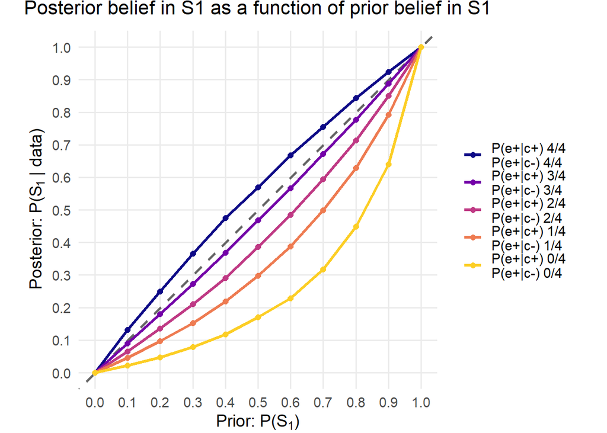

```r
library(ggplot2)

ggplot(pred_SI_all, aes(x = prior_S1, y = S1_pp, color = contingency, group = contingency)) +
  # 45° reference line
  geom_abline(slope = 1, intercept = 0, linetype = "dashed", color = "gray40", linewidth = 1) +
  geom_line(linewidth = 1.2) +
  geom_point(size = 2) +
  scale_x_continuous(
    name = expression("Prior: P(S"[1]*")"),
    breaks = seq(0, 1, 0.1),
    limits = c(0, 1)
  ) +
  scale_y_continuous(
    name = expression("Posterior: P(S"[1]*" | data)"),
    breaks = seq(0, 1, 0.1),
    limits = c(0, 1)
  ) +
  scale_color_viridis_d(option = "C", end = 0.9) +
  theme_minimal(base_size = 14) +
  theme(
    legend.position = "right",
    legend.title = element_blank(),
    panel.grid.minor = element_blank(),
    plot.title = element_text(size = 16, face = "bold", hjust = 0.5)
  ) +
  ggtitle(expression("Posterior belief in S1 as a function of prior belief in S1")) +
  coord_equal()+
  theme(
    plot.margin = margin(t = 0, r = 0, b = 0, l = 0)
  )
```

```r
# save plot as svg

ggsave("SI_model_prior_vs_posterior_S1_N8.svg", width = 7, height = 5)
ggsave("SI_model_prior_vs_posterior_S1_N8.pdf", width = 7, height = 5)
```

```r
library(ggnewscale)
```

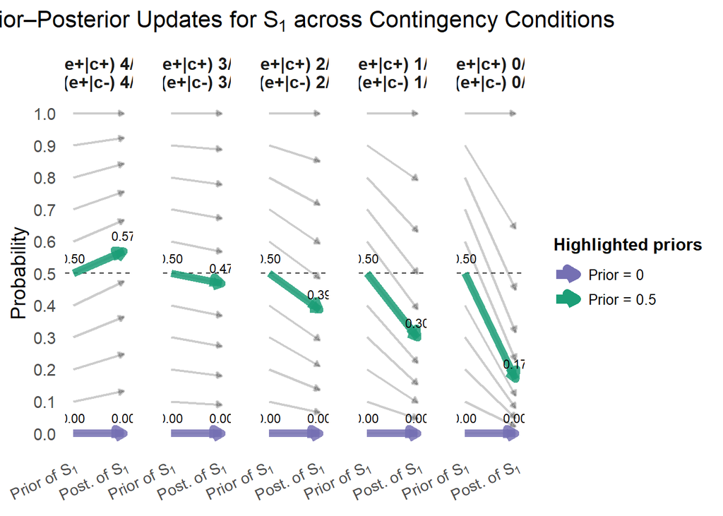

```r
library(dplyr)
library(tidyr)
library(ggplot2)
library(grid)

# --- Prepare data ---
seg <- pred_SI_all %>%
  select(contingency, prior_S1, S1_pp) %>%
  transmute(
    contingency,
    id   = prior_S1,
    x0   = 0,   # Prior of S1
    x1   = 1,   # Posterior of S1
    y0   = prior_S1,
    y1   = S1_pp
  )

# Highlighted priors
seg_hi <- seg %>%
  filter(near(id, 0) | near(id, 0.5)) %>%
  mutate(highlight_label = ifelse(near(id, 0), "Prior = 0", "Prior = 0.5"))

# Endpoints for points + labels
endpts_hi <- seg_hi %>%
  tidyr::pivot_longer(c(x0, x1, y0, y1),
                      names_to = c(".value","which"),
                      names_pattern = "([xy])(\\d)") %>%
  mutate(
    which = ifelse(which == "0", "Prior of S1", "Posterior of S1"),
    x = ifelse(which == "Prior of S1", 0, 1),
    y = y
  )

# --- Plot ---
ggplot() +
  # Reference line at y = 50
    geom_hline(yintercept = 0.50, color = "grey20", linewidth = 0.4, linetype = "dashed") +
  # faint background arrows
  geom_segment(
    data = seg,
    aes(x = x0, xend = x1, y = y0, yend = y1),
    color = "black",
    linewidth = 0.8, alpha = 0.2,
    arrow = arrow(length = unit(0.15, "cm"), type = "closed")
  ) +

  # highlighted arrows (two distinct colors)
  geom_segment(
    data = seg_hi,
    aes(x = x0, xend = x1, y = y0, yend = y1, color = highlight_label),
    linewidth = 2.5, alpha = 0.85,
    arrow = arrow(length = unit(0.25, "cm"), type = "closed")
  ) +
  #geom_point(data = endpts_hi,aes(x = x, y = y, color = highlight_label),size = 3, alpha = 0.9) +
  geom_text(data = endpts_hi,
            aes(x = x, y = y, label = sprintf("%.2f", y)),
            vjust = -1.1, size = 3, color = "black") +

  facet_wrap(~contingency, nrow = 1) +
  scale_color_manual(
    name = "Highlighted priors",
    values = c(
      "Prior = 0"   = "#7570b3",  # red-orange #1b9e77", "transparent" = "#7570b3
      "Prior = 0.5" = "#1b9e77"   # teal
    ),
    guide = guide_legend(
      title.position = "top",
      override.aes = list(linewidth = 3, alpha = 1)
    )
  ) +
  scale_x_continuous(
    breaks = c(0, 1),
    labels = c(expression("Prior of S"[1]),
               expression("Post. of S"[1])),
    limits = c(-0.1, 1.1),
    name = NULL
  ) +
  scale_y_continuous(
    name = "Probability",
    limits = c(0, 1),
    breaks = seq(0, 1, 0.1)
  ) +
  theme_minimal(base_size = 14) +
  theme(
  # …your other theme settings…
  panel.grid.major.x = element_blank(),
  panel.grid.minor.x = element_blank(),
  panel.grid.minor.y = element_blank(),
  panel.grid.major.y = element_blank(),
  panel.spacing.x = unit(1.5, "lines"),   # <-- NEW LINE: adds space between facets
  legend.position = "right",
  legend.title = element_text(size = 12, face = "bold"),
  legend.text = element_text(size = 10),
  strip.text = element_text(face = "bold", size = 12),
  plot.title = element_text(size = 16, face = "bold", hjust = 0.5),
  axis.text.x = element_text(size = 11,angle = 25, hjust = 1)
)+
  labs(
    title = expression("Prior–Posterior Updates for S"[1]*" across Contingency Conditions")
  )-> g_update_highlight

g_update_highlight
```

```r
# Save plot
#ggsave("SI_model_prior_posterior_updates_highlight.svg", plot = g_update_highlight, width = 14, height = 5)
```

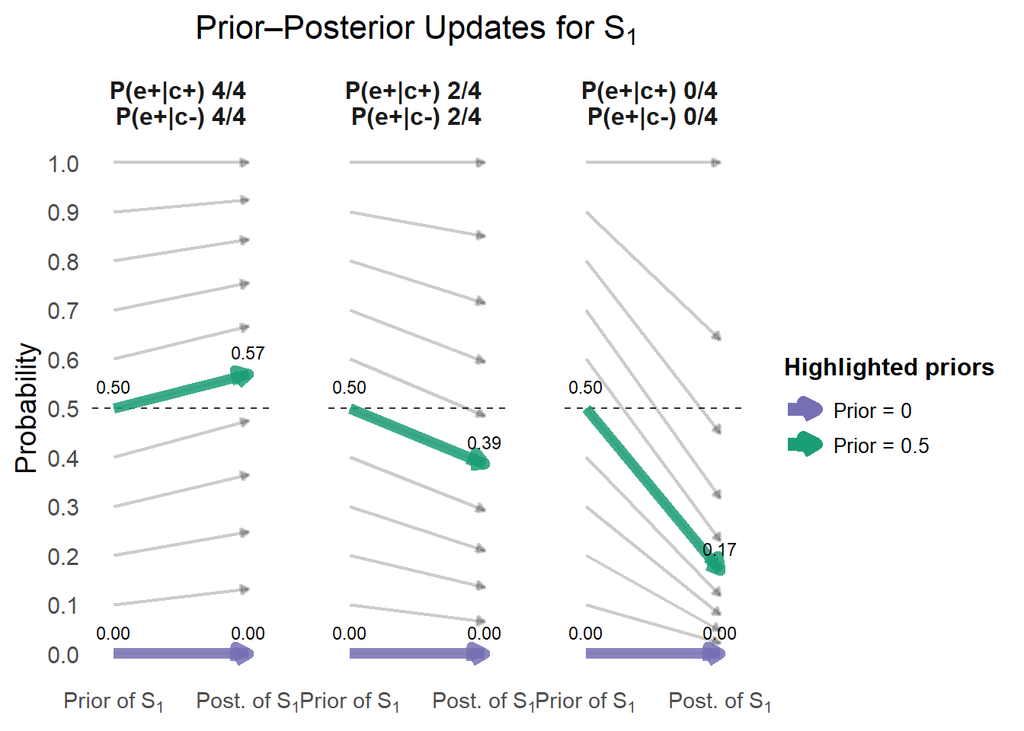

```r
library(ggnewscale)
library(dplyr)
library(tidyr)
library(ggplot2)
library(grid)

# --- Subset contingencies of interest (8/8, 4/4, 0/0) ---
subset_data <- pred_SI_all %>%
  filter(N_11 %in% c(4, 2, 0))

# --- Prepare data ---
seg <- subset_data %>%
  select(contingency, prior_S1, S1_pp) %>%
  transmute(
    contingency,
    id   = prior_S1,
    x0   = 0,   # Prior of S1
    x1   = 1,   # Posterior of S1
    y0   = prior_S1,
    y1   = S1_pp
  )

# Highlighted priors
seg_hi <- seg %>%
  filter(near(id, 0) | near(id, 0.5)) %>%
  mutate(highlight_label = ifelse(near(id, 0), "Prior = 0", "Prior = 0.5"))

# Endpoints for points + labels
endpts_hi <- seg_hi %>%
  tidyr::pivot_longer(c(x0, x1, y0, y1),
                      names_to = c(".value","which"),
                      names_pattern = "([xy])(\\d)") %>%
  mutate(
    which = ifelse(which == "0", "Prior of S1", "Posterior of S1"),
    x = ifelse(which == "Prior of S1", 0, 1),
    y = y
  )

# --- Plot ---
ggplot() +
  geom_hline(yintercept = 0.50, color = "grey20", linewidth = 0.4, linetype = "dashed") +
  geom_segment(
    data = seg,
    aes(x = x0, xend = x1, y = y0, yend = y1),
    color = "black",
    linewidth = 0.8, alpha = 0.2,
    arrow = arrow(length = unit(0.15, "cm"), type = "closed")
  ) +
  geom_segment(
    data = seg_hi,
    aes(x = x0, xend = x1, y = y0, yend = y1, color = highlight_label),
    linewidth = 2.5, alpha = 0.85,
    arrow = arrow(length = unit(0.25, "cm"), type = "closed")
  ) +
  geom_text(data = endpts_hi,
            aes(x = x, y = y, label = sprintf("%.2f", y)),
            vjust = -1.1, size = 3, color = "black") +
  facet_wrap(~contingency, nrow = 1) +
  scale_color_manual(
    name = "Highlighted priors",
    values = c(
      "Prior = 0"   = "#7570b3",
      "Prior = 0.5" = "#1b9e77"
    ),
    guide = guide_legend(
      title.position = "top",
      override.aes = list(linewidth = 3, alpha = 1)
    )
  ) +
  scale_x_continuous(
    breaks = c(0, 1),
    labels = c(expression("Prior of S"[1]),
               expression("Post. of S"[1])),
    limits = c(-0.1, 1.1),
    name = NULL
  ) +
  scale_y_continuous(
    name = "Probability",
    limits = c(0, 1),
    breaks = seq(0, 1, 0.1)
  ) +
  theme_minimal(base_size = 14) +
  theme(
    panel.grid.major.x = element_blank(),
    panel.grid.minor.x = element_blank(),
    panel.grid.minor.y = element_blank(),
    panel.grid.major.y = element_blank(),
    panel.spacing.x = unit(2, "lines"),
    legend.position = "right",
    legend.title = element_text(size = 12, face = "bold"),
    legend.text = element_text(size = 10),
    strip.text = element_text(face = "bold", size = 12),
    plot.title = element_text(size = 16, face = "bold", hjust = 0.5),
    axis.text.x = element_text(size = 11, angle = 0, hjust = 0.5)
  ) +
  labs(
    title = expression("Prior–Posterior Updates for S"[1]*"")
  ) -> g_update_highlight_subset

g_update_highlight_subset
```

```r
# Save subset plot
ggsave("SI_model_prior_posterior_updates_highlight_subset_N8.svg",
       plot = g_update_highlight_subset, width = 10, height = 4)

ggsave("SI_model_prior_posterior_updates_highlight_subset_N8.pdf",
       plot = g_update_highlight_subset, width = 10, height = 4)
```

# Get and prepare raw data

```r
# read that csv again
data <- read.csv("data.csv")
```

```r
table(data$machine, data$contingency)
```

```
##
##          0_0 05_05 1_1
##   opaque  67    70  54
##   transp  77    69  64
```

Exclude participants whose learning accuracy (coded in “learning_yellow_accuracy” and “learning_pink_accuracy”) is less than 0.875

```r
data_learning_exclusion <- data %>%
  filter(learning_yellow_accuracy < 7/8 | learning_pink_accuracy < 7/8)


data <- data %>%
  filter(learning_yellow_accuracy >= 7/8 & learning_pink_accuracy >= 7/8)
```

```r
total_N <- nrow(data) + nrow(data_learning_exclusion)
# percentage excluded
excl_percentage <- (nrow(data_learning_exclusion) / total_N) * 100
excl_percentage
```

```
## [1] 25.18703
```

```r
table(data$machine, data$contingency)
```

```
##
##          0_0 05_05 1_1
##   opaque  50    50  50
##   transp  50    50  50
```

```r
table(data$condition)
```

```
##
##  1  2  5  6  9 10
## 50 50 50 50 50 50
```

# Analysis

```r
# relable factor "str_query_type" so that "prob" becomes "agree"

data$contingency <- factor(data$contingency,
                              levels = c("1_1", "075_075", "05_05", "025_025", "0_0"),
                              labels = c("P(e+|c+) 4/4 \nP(e+|c-) 4/4", "P(e+|c+) 3/4 \nP(e+|c-) 3/4", "P(e+|c+) 2/4 \nP(e+|c-) 2/4",
                                         "P(e+|c+) 1/4 \nP(e+|c-) 1/4", "P(e+|c+) 0/4 \nP(e+|c-) 0/4"))


data$machine <- factor(data$machine,
                              levels = c("opaque", "transp"),
                              labels = c("opaque", "transparent"))



table(data$machine, data$contingency)
```

```
##
##               P(e+|c+) 4/4 \nP(e+|c-) 4/4 P(e+|c+) 3/4 \nP(e+|c-) 3/4
##   opaque                               50                           0
##   transparent                          50                           0
##
##               P(e+|c+) 2/4 \nP(e+|c-) 2/4 P(e+|c+) 1/4 \nP(e+|c-) 1/4
##   opaque                               50                           0
##   transparent                          50                           0
##
##               P(e+|c+) 0/4 \nP(e+|c-) 0/4
##   opaque                               50
##   transparent                          50
```

```r
descriptives_prior <- data %>%
  group_by(machine, contingency) %>%
  summarise(
    mean_confidence = mean(structure_rating_prior, na.rm = TRUE),
    sd_confidence   = sd(structure_rating_prior, na.rm = TRUE)
  )
descriptives_prior
```

```
## # A tibble: 6 × 4
## # Groups:   machine [2]
##   machine     contingency                   mean_confidence sd_confidence
##   <fct>       <fct>                                   <dbl>         <dbl>
## 1 opaque      "P(e+|c+) 4/4 \nP(e+|c-) 4/4"           48.3           24.0
## 2 opaque      "P(e+|c+) 2/4 \nP(e+|c-) 2/4"           51.4           27.0
## 3 opaque      "P(e+|c+) 0/4 \nP(e+|c-) 0/4"           54.8           20.0
## 4 transparent "P(e+|c+) 4/4 \nP(e+|c-) 4/4"           14.5           25.0
## 5 transparent "P(e+|c+) 2/4 \nP(e+|c-) 2/4"           19.6           29.4
## 6 transparent "P(e+|c+) 0/4 \nP(e+|c-) 0/4"            8.08          16.0
```

```r
descriptives_post <- data %>%
  group_by(machine, contingency) %>%
  summarise(
    mean_confidence = mean(structure_rating_posterior, na.rm = TRUE),
    sd_confidence   = sd(structure_rating_posterior, na.rm = TRUE)
  )
descriptives_post
```

```
## # A tibble: 6 × 4
## # Groups:   machine [2]
##   machine     contingency                   mean_confidence sd_confidence
##   <fct>       <fct>                                   <dbl>         <dbl>
## 1 opaque      "P(e+|c+) 4/4 \nP(e+|c-) 4/4"           54.8          28.7
## 2 opaque      "P(e+|c+) 2/4 \nP(e+|c-) 2/4"           40.1          29.6
## 3 opaque      "P(e+|c+) 0/4 \nP(e+|c-) 0/4"           33.1          21.6
## 4 transparent "P(e+|c+) 4/4 \nP(e+|c-) 4/4"           20.2          29.3
## 5 transparent "P(e+|c+) 2/4 \nP(e+|c-) 2/4"           19.8          29.5
## 6 transparent "P(e+|c+) 0/4 \nP(e+|c-) 0/4"            3.62          8.93
```

# Plots

```r
machine_colors <- c(
  # Dark2 Colors (Colors 1-8)
  "opaque"      = "#1b9e77",  # Dark2 Green
  "1.0 \n0.5"   = "#d95f02",  # Dark2 Orange
  "transparent"   = "#7570b3",  # Dark2 Purple
  "0.25 \n0.25" = "#e7298a",  # Dark2 Pink/Magenta
  "0.75 \n0.75" = "#66a61e",  # Dark2 Light Green
  "0.625 \n0.5" = "#e6ab02",  # Dark2 Yellow/Brown
  "0.875 \n0.5" = "#a6761d"   # Dark2 Brown (The added color)

  # Note: The 8th Dark2 color is #666666 (Dark Gray), which you could use if you had an 8th condition.
)
```

Now make a data frame in long format for plotting prior and posterior structure ratings together

```r
# make a separate data frame in long format for plotting, with the DVs being "structure_rating_prior" and "strucutre_rating_posterior"
data_long <- data %>%
  pivot_longer(cols = c(structure_rating_prior, structure_rating_posterior),
               names_to = "rating_type",
               values_to = "rating_value")

# make rating_type a factor with levels in the desired order
data_long$rating_type <- factor(data_long$rating_type, levels = c("structure_rating_prior", "structure_rating_posterior"),
                                labels = c("Prior", "Posterior"))
```

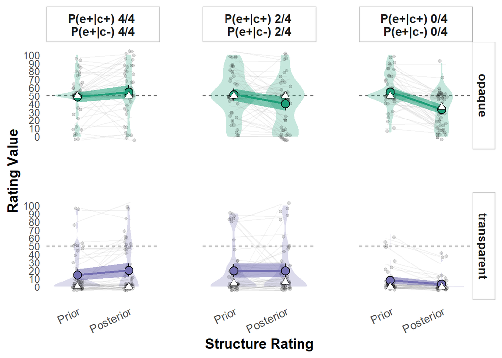

```r
library(dplyr)
library(ggplot2)
library(Hmisc)  # for mean_cl_boot
plotDV <- function(df, dv_col, x_jitter = 0.10, y_jitter = 5) {


  ggplot(df, aes(x = rating_type, y = .data[[dv_col]], fill = machine)) +
    facet_grid(machine ~ contingency) +
    scale_y_continuous(limits = c(-10, 110), breaks = seq(0, 100, by = 10)) +

    # Reference line at y = 50
    geom_hline(yintercept = 50, color = "grey20", linewidth = 0.4, linetype = "dashed") +

    # Violin background (lighter, no outline)
    geom_violin(
      trim = TRUE, alpha = 0.25,
      color = NA
    ) +

    # Subject lines (jittered both horizontally & vertically)
    geom_line(
      aes(group = subj_code),
      alpha = 0.1,
      color = "grey50",
      position = position_jitter(width = x_jitter, height = y_jitter)
    ) +

    # Jittered points
    geom_point(
      alpha = 0.15,
      size = 1.2,
      color = "black",
      position = position_jitter(width = x_jitter, height = y_jitter)
    ) +

    # Bootstrapped mean ±95% CI ribbons (higher alpha)
    stat_summary(
      aes(group = machine, fill = machine),
      fun.data = mean_cl_boot,
      geom = "ribbon",
      alpha = 0.55,
      color = NA
    ) +

    # Mean line (per machine)
    stat_summary(
      aes(color = machine, group = machine),
      fun = mean,
      geom = "line",
      size = 1
    ) +

    # Mean point with thin black border
    stat_summary(
      aes(fill = machine),
      fun.data = mean_cl_boot,
      geom = "pointrange",
      shape = 21,
      color = "black",
      size = 0.9,
      stroke = 0.6
    ) +

    # Median point (white triangle)
    stat_summary(
      fun = median,
      geom = "point",
      shape = 24,
      size = 2.5,
      fill = "white",
      color = "black"
    ) +

    # Color scales
    scale_fill_manual(values = machine_colors) +
    scale_color_manual(values = machine_colors) +

    labs(
      x = "Structure Rating",
      y = "Rating Value"
    ) +

    # APA-friendly theme (no gridlines)
    theme_minimal(base_size = 14) +
    theme(
      legend.position = "none",
      axis.text.x = element_text(angle = 25, hjust = 1),
      axis.text.y = element_text(size = 10),
      panel.spacing = unit(3, "lines"),
      panel.grid = element_blank(),
      strip.background = element_rect(fill = "white", color = "grey70", linewidth = 0.4),
      strip.text = element_text(face = "bold", size = 12),
      axis.title = element_text(face = "bold")
    )
}

# ---- Run and Save ----
p1 <- plotDV(data_long, "rating_value")
p1
```

```r
ggsave("structure_rating_by_machine_APA_colored.svg", plot = p1, width = 8, height = 6)
ggsave("structure_rating_by_machine_APA_colored.pdf", plot = p1, width = 8, height = 6)
```

Test the difference between prior and posterior structure ratings depending on machine and contingency condition using a mixed ANOVA with contingency and machine as between-subject factors and rating_type (prior vs. posterior) as within-subject factor

```r
anova_data <- data %>%
  select(subj_code, machine, contingency, structure_rating_prior, structure_rating_posterior) %>%
  pivot_longer(cols = c(structure_rating_prior, structure_rating_posterior),
               names_to = "rating_type",
               values_to = "rating_value")

anova_data$rating_type <- factor(anova_data$rating_type, levels = c("structure_rating_prior", "structure_rating_posterior"),
                                labels = c("Prior", "Posterior"))
```

```r
library(afex)
library(emmeans)
a1 <- aov_car(rating_value ~ contingency*machine*rating_type  + Error(subj_code/rating_type), anova_data, anova_table = list(es = "pes")) # the anova model
```

```
## Contrasts set to contr.sum for the following variables: contingency, machine
```

```r
a1
```

```
## Anova Table (Type 3 tests)
##
## Response: rating_value
##                            Effect     df    MSE          F  pes p.value
## 1                     contingency 2, 294 940.20    5.50 ** .036    .005
## 2                         machine 1, 294 940.20 171.57 *** .369   <.001
## 3             contingency:machine 2, 294 940.20       2.01 .013    .136
## 4                     rating_type 1, 294 297.57    8.67 ** .029    .003
## 5         contingency:rating_type 2, 294 297.57  15.77 *** .097   <.001
## 6             machine:rating_type 1, 294 297.57   10.88 ** .036    .001
## 7 contingency:machine:rating_type 2, 294 297.57     3.54 * .023    .030
## ---
## Signif. codes:  0 '***' 0.001 '**' 0.01 '*' 0.05 '+' 0.1 ' ' 1
```

```r
# means
group_means <- emmeans(a1, c("rating_type", "contingency", "machine"))
group_means
```

```
##  rating_type  contingency                machine     emmean   SE  df lower.CL
##  Prior       P(e+|c+) 4/4 \nP(e+|c-) 4/4 opaque       48.28 3.39 294    41.60
##  Posterior   P(e+|c+) 4/4 \nP(e+|c-) 4/4 opaque       54.82 3.64 294    47.66
##  Prior       P(e+|c+) 2/4 \nP(e+|c-) 2/4 opaque       51.38 3.39 294    44.70
##  Posterior   P(e+|c+) 2/4 \nP(e+|c-) 2/4 opaque       40.14 3.64 294    32.98
##  Prior       P(e+|c+) 0/4 \nP(e+|c-) 0/4 opaque       54.80 3.39 294    48.12
##  Posterior   P(e+|c+) 0/4 \nP(e+|c-) 0/4 opaque       33.12 3.64 294    25.96
##  Prior       P(e+|c+) 4/4 \nP(e+|c-) 4/4 transparent  14.46 3.39 294     7.78
##  Posterior   P(e+|c+) 4/4 \nP(e+|c-) 4/4 transparent  20.24 3.64 294    13.08
##  Prior       P(e+|c+) 2/4 \nP(e+|c-) 2/4 transparent  19.60 3.39 294    12.92
##  Posterior   P(e+|c+) 2/4 \nP(e+|c-) 2/4 transparent  19.78 3.64 294    12.62
##  Prior       P(e+|c+) 0/4 \nP(e+|c-) 0/4 transparent   8.08 3.39 294     1.40
##  Posterior   P(e+|c+) 0/4 \nP(e+|c-) 0/4 transparent   3.62 3.64 294    -3.54
##  upper.CL
##      55.0
##      62.0
##      58.1
##      47.3
##      61.5
##      40.3
##      21.1
##      27.4
##      26.3
##      26.9
##      14.8
##      10.8
##
## Confidence level used: 0.95
```

compute a contrast with emmeans to test if the prior-posterior change is larger in the opaque machine condition compared to the transparent machine condition, across all contingency conditions

```r
pairs(emmeans(a1, ~ rating_type|machine), adjust = "none") -> deltas

deltas
```

```
## machine = opaque:
##  contrast          estimate   SE  df t.ratio p.value
##  Prior - Posterior     8.79 1.99 294   4.415  <.0001
##
## machine = transparent:
##  contrast          estimate   SE  df t.ratio p.value
##  Prior - Posterior    -0.50 1.99 294  -0.251  0.8020
##
## Results are averaged over the levels of: contingency
```

```r
pairs(emmeans(a1, ~ rating_type|contingency*machine), adjust = "none") -> deltas

deltas
```

```
## contingency = P(e+|c+) 4/4
## P(e+|c-) 4/4, machine = opaque:
##  contrast          estimate   SE  df t.ratio p.value
##  Prior - Posterior    -6.54 3.45 294  -1.896  0.0590
##
## contingency = P(e+|c+) 2/4
## P(e+|c-) 2/4, machine = opaque:
##  contrast          estimate   SE  df t.ratio p.value
##  Prior - Posterior    11.24 3.45 294   3.258  0.0013
##
## contingency = P(e+|c+) 0/4
## P(e+|c-) 0/4, machine = opaque:
##  contrast          estimate   SE  df t.ratio p.value
##  Prior - Posterior    21.68 3.45 294   6.284  <.0001
##
## contingency = P(e+|c+) 4/4
## P(e+|c-) 4/4, machine = transparent:
##  contrast          estimate   SE  df t.ratio p.value
##  Prior - Posterior    -5.78 3.45 294  -1.675  0.0949
##
## contingency = P(e+|c+) 2/4
## P(e+|c-) 2/4, machine = transparent:
##  contrast          estimate   SE  df t.ratio p.value
##  Prior - Posterior    -0.18 3.45 294  -0.052  0.9584
##
## contingency = P(e+|c+) 0/4
## P(e+|c-) 0/4, machine = transparent:
##  contrast          estimate   SE  df t.ratio p.value
##  Prior - Posterior     4.46 3.45 294   1.293  0.1971
```

Compute the different between prior and posterior for each participant and append it to data frame

```r
data <- data %>%
  mutate(rating_diff = structure_rating_posterior - structure_rating_prior)
```

```r
data <- data %>%
  mutate(rating_diff_type = case_when(
    rating_diff > 0 ~ "increase",
    rating_diff < 0 ~ "decrease",
    TRUE ~ "same"
  ))
```

Now make a plot that shows the proportions of these rating_diff_type for each machine and contingency condition; as error bars, show 95% Proportion CIs (using binom.confint from the binom package)

```r
library(binom)
data_diff_type <- data %>%
  group_by(machine, contingency, rating_diff_type) %>%
  summarise(
    count = n()
  ) %>%
  group_by(machine, contingency) %>%
  mutate(
    total = sum(count),
    proportion = count / total
  ) %>%
  ungroup()
```

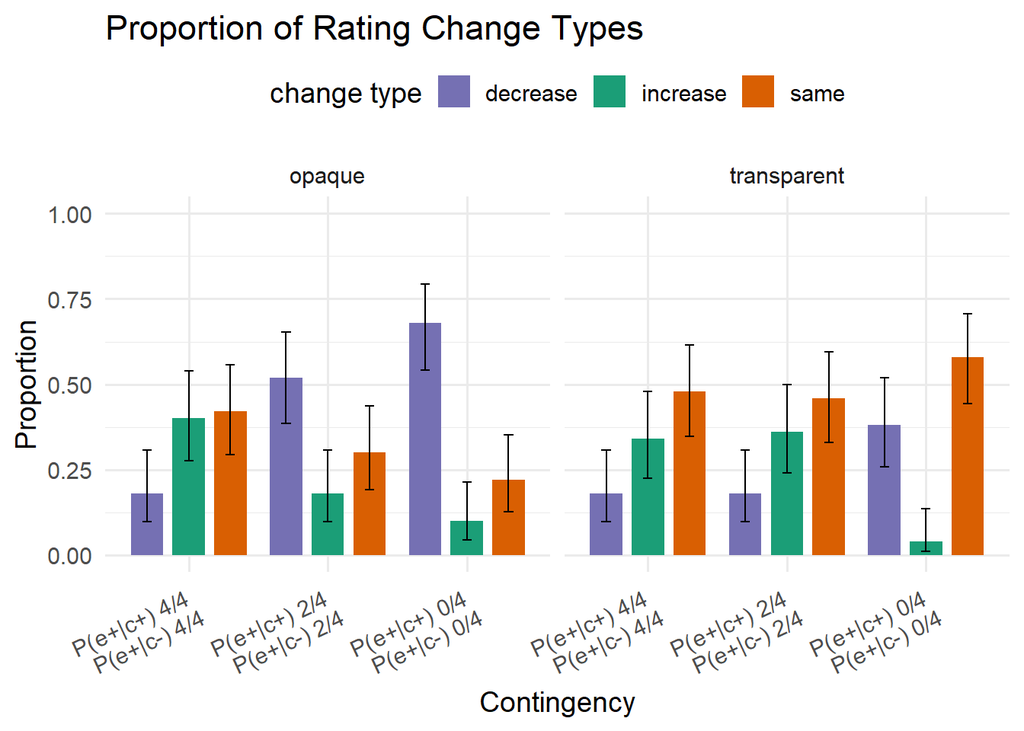

```r
# compute 95% CIs for proportions
data_diff_type <- data_diff_type %>%
  rowwise() %>%
  mutate(
    ci = list(binom.confint(count, total, method = "wilson"))
  ) %>%
  unnest_wider(ci) %>%
  select(-c(method, mean, x))


ggplot(data_diff_type, aes(x = contingency, y = proportion, fill = rating_diff_type)) +
  facet_wrap(~ machine) +
  geom_bar(stat = "identity", position = position_dodge(width = 0.9), width = 0.7) +
  geom_errorbar(aes(ymin = lower, ymax = upper),
                position = position_dodge(width = 0.9), width = 0.2) +
  scale_fill_manual(values = c("increase" = "#1b9e77", "same" = "#d95f02", "decrease" = "#7570b3")) +
  labs(
    title = "Proportion of Rating Change Types",
    x = "Contingency",
    y = "Proportion",
    fill = "change type"
  ) +
  theme_minimal(base_size = 14) +
  theme(
    legend.position = "top",
    axis.text.x = element_text(angle = 25, hjust = 1)
  )+ # define y axis limits so that they go from 0 to 1 in steps of 0.25
  scale_y_continuous(limits = c(0, 1), breaks = seq(0, 1, by = 0.25))-> p3
p3
```

```r
# save plot
ggsave("subgroups.svg", plot = p3, width = 14, height = 6)
ggsave("subgroups.pdf", plot = p3, width = 14, height = 6)
```